# 10114 - Analyze capture-mark-recapture data using *mrmr*

Roland Knapp

## CMR analysis - Goddard 10114

This notebook analyzes capture-mark-recapture data using the *mrmr* package. The code creates the required survey, capture, and translocation data frames from saved CSV files (created by 10114_createdata_mrmr.Rmd), checks the datasets, fits the model, evaluates potential non-convergence of the MCMC algorithm, and visualizes model results.

Before using the code in this file, replace all instances of “xxxxx” with the 5-digit site_id of interest.

## Install latest versions of cmdstanr, cmdstan, and mrmr packages

- Run only if updated versions were released since previous install.

```r
# install mrmr
remotes::install_github("SNARL1/mrmr")
```

## Load required packages

```r
library(dplyr)
library(readr)
library(tibble)
library(cmdstanr)
library(mrmr)
library(patchwork)
```

## Create required datasets

```r
translocations <- read_csv(here::here("data", "clean", "10114_reintroduction.csv"))
```

## Check datasets

```r
data_10114
```

```
$stan_d
$stan_d$M
[1] 414

$stan_d$T
[1] 5

$stan_d$maxJ
[1] 3

$stan_d$J
n_sec_periods1 n_sec_periods2 n_sec_periods3 n_sec_periods4 n_sec_periods5
             0              3              0              3              0

$stan_d$Jtot
```

[output cut: 728 more lines]

| site_id | survey_date | pit_tag_id |
| --- | --- | --- |
| 10114 | 2022-07-19 | 900043000200910 |
| 10114 | 2022-07-19 | 982091062745746 |
| 10114 | 2022-07-19 | 982091062745765 |
| 10114 | 2022-07-19 | 982091062745770 |
| 10114 | 2022-07-19 | 982091062745903 |
| 10114 | 2022-07-20 | 900043000200595 |
| 10114 | 2022-07-20 | 900043000200910 |
| 10114 | 2022-07-20 | 982091062745746 |
| 10114 | 2022-07-20 | 982091062745765 |
| 10114 | 2022-07-20 | 982091062745900 |

[output cut: 13 more lines]

| site_id | type | release_date | pit_tag_id | survey_date | primary_period | secondary_period | year | is_overwinter |
| --- | --- | --- | --- | --- | --- | --- | --- | --- |
| 10114 | reintroduction | 2022-07-21 | 900043000215607 | 2022-07-21 | 3 | 0 | 2022 | TRUE |
| 10114 | reintroduction | 2022-07-21 | 900043000215610 | 2022-07-21 | 3 | 0 | 2022 | TRUE |
| 10114 | reintroduction | 2022-07-21 | 900043000215625 | 2022-07-21 | 3 | 0 | 2022 | TRUE |
| 10114 | reintroduction | 2022-07-21 | 900043000215628 | 2022-07-21 | 3 | 0 | 2022 | TRUE |
| 10114 | reintroduction | 2022-07-21 | 900043000215634 | 2022-07-21 | 3 | 0 | 2022 | TRUE |
| 10114 | reintroduction | 2022-07-21 | 900043000215642 | 2022-07-21 | 3 | 0 | 2022 | TRUE |
| 10114 | reintroduction | 2022-07-21 | 900043000215644 | 2022-07-21 | 3 | 0 | 2022 | TRUE |
| 10114 | reintroduction | 2022-07-21 | 900043000215646 | 2022-07-21 | 3 | 0 | 2022 | TRUE |
| 10114 | reintroduction | 2022-07-21 | 900043000215658 | 2022-07-21 | 3 | 0 | 2022 | TRUE |
| 10114 | reintroduction | 2022-07-21 | 900043000215660 | 2022-07-21 | 3 | 0 | 2022 | TRUE |

[output cut: 116 more lines]

| primary_period | secondary_period | survey_date | year | is_overwinter |
| --- | --- | --- | --- | --- |
| 1 | 0 | 2022-07-04 | 2022 | FALSE |
| 2 | 1 | 2022-07-18 | 2022 | FALSE |
| 2 | 2 | 2022-07-19 | 2022 | FALSE |
| 2 | 3 | 2022-07-20 | 2022 | FALSE |
| 3 | 0 | 2022-07-21 | 2022 | TRUE |
| 4 | 1 | 2023-08-25 | 2023 | FALSE |
| 4 | 2 | 2023-08-26 | 2023 | FALSE |
| 4 | 3 | 2023-08-27 | 2023 | FALSE |
| 5 | 0 | 2023-08-28 | 2023 | FALSE |

```
$removals
[1] NA

$survival_covariate_df
```

| pit_tag_id |
| --- |
| 900043000200565 |
| 900043000200595 |
| 900043000200649 |
| 900043000200655 |
| 900043000200900 |
| 900043000200910 |
| 900043000215607 |
| 900043000215610 |
| 900043000215625 |
| 900043000215628 |

[output cut: 404 more lines]

```
NA
```

## Fit model

- Code assumes that there are 8 physical cores available. Update parallel_chains and threads_per_chain as necessary based on actual number of cores.
- Add “adapt_delta = 0.99” or similar (after “treats_per_chain”) if divergent transitions occur.

```r
model_10114 <- fit_model(
                    data = data_10114,
                    chains = 4,
                    parallel_chains = 4,
                    cpp_options = list(stan_threads = TRUE),
                    threads_per_chain = 2)
```

[output not shown]

[output cut: 212 more lines]

[output not shown]

[output not shown]

[output not shown]

[output not shown]

[output not shown]

[output not shown]

[output not shown]

[output not shown]

[output not shown]

[output not shown]

[output not shown]

[output not shown]

[output not shown]

[output not shown]

[output not shown]

[output not shown]

[output not shown]

[output cut: 440 more lines]

[output not shown]

[output not shown]

[output not shown]

[output not shown]

[output not shown]

[output not shown]

[output not shown]

[output not shown]

[output not shown]

[output not shown]

[output not shown]

[output not shown]

[output not shown]

[output not shown]

[output not shown]

[output not shown]

[output not shown]

[output cut: 231 more lines]

```
/

-

\


/


Running MCMC with 4 parallel chains, with 2 thread(s) per chain...

Chain 1 Iteration:    1 / 2000 [  0%]  (Warmup)
Chain 2 Iteration:    1 / 2000 [  0%]  (Warmup)
Chain 3 Iteration:    1 / 2000 [  0%]  (Warmup)
```

```
Chain 3 Informational Message: The current Metropolis proposal is about to be rejected because of the following issue:
Chain 3 Exception: offset_multiplier_constrain: multiplier is inf, but must be positive finite! (in 'C:/Users/tcoll/AppData/Local/Temp/RtmpGOlfvT/model-5c4465ee30d9.stan', line 190, column 2 to column 42)
Chain 3 If this warning occurs sporadically, such as for highly constrained variable types like covariance matrices, then the sampler is fine,
Chain 3 but if this warning occurs often then your model may be either severely ill-conditioned or misspecified.
Chain 3
```

[output not shown]

[output cut: 38 more lines]

```
Chain 3 Iteration: 1900 / 2000 [ 95%]  (Sampling)
Chain 2 Iteration: 2000 / 2000 [100%]  (Sampling)
Chain 2 finished in 216.6 seconds.
Chain 4 Iteration: 1600 / 2000 [ 80%]  (Sampling)
Chain 3 Iteration: 2000 / 2000 [100%]  (Sampling)
Chain 3 finished in 219.1 seconds.
Chain 4 Iteration: 1700 / 2000 [ 85%]  (Sampling)
Chain 4 Iteration: 1800 / 2000 [ 90%]  (Sampling)
Chain 4 Iteration: 1900 / 2000 [ 95%]  (Sampling)
Chain 4 Iteration: 2000 / 2000 [100%]  (Sampling)
Chain 4 finished in 255.6 seconds.

All 4 chains finished successfully.
Mean chain execution time: 222.9 seconds.
Total execution time: 255.8 seconds.
```

- Running model with default adapt_delta (0.8) resulted in zero divergent transition (0/4000).

### Save model object

```r
model_10114
```

| variable | mean | median | sd | mad | q5 | q95 | rhat | ess_bulk | ess_tail |
| --- | --- | --- | --- | --- | --- | --- | --- | --- | --- |
| lp__ | -104.16 | -103.73 | 3.21 | 3.09 | -110.08 | -99.64 | 1.00 | 1141 | 1381 |
| alpha_lambda | -1.32 | -1.31 | 1.39 | 1.68 | -3.50 | 0.86 | 1.00 | 928 | 1380 |
| sigma_lambda | 1.47 | 1.47 | 0.67 | 0.64 | 0.29 | 2.58 | 1.00 | 1173 | 659 |
| eps_lambda[1] | 0.20 | 0.20 | 1.14 | 1.27 | -1.65 | 1.98 | 1.00 | 1240 | 2700 |
| eps_lambda[2] | -1.19 | -1.19 | 0.76 | 0.71 | -2.44 | 0.02 | 1.00 | 2268 | 1733 |
| eps_lambda[3] | 0.11 | 0.11 | 1.04 | 1.05 | -1.56 | 1.82 | 1.00 | 5023 | 2983 |
| eps_lambda[4] | -0.62 | -0.74 | 0.92 | 0.85 | -1.96 | 1.03 | 1.00 | 1855 | 2733 |
| eps_lambda[5] | -0.01 | -0.02 | 1.00 | 0.98 | -1.64 | 1.66 | 1.00 | 6395 | 2757 |
| beta_phi[1] | -1.11 | -1.11 | 0.98 | 1.00 | -2.74 | 0.47 | 1.00 | 1730 | 1243 |
| sigma_phi | 1.77 | 1.76 | 0.67 | 0.64 | 0.66 | 2.91 | 1.00 | 1634 | 728 |

```
 # showing 10 of 2106 rows (change via 'max_rows' argument or 'cmdstanr_max_rows' option)

$data
$data$stan_d
$data$stan_d$M
[1] 414

$data$stan_d$T
[1] 5

$data$stan_d$maxJ
[1] 3

$data$stan_d$J
n_sec_periods1 n_sec_periods2 n_sec_periods3 n_sec_periods4 n_sec_periods5
```

[output cut: 731 more lines]

| site_id | survey_date | pit_tag_id |
| --- | --- | --- |
| 10114 | 2022-07-19 | 900043000200910 |
| 10114 | 2022-07-19 | 982091062745746 |
| 10114 | 2022-07-19 | 982091062745765 |
| 10114 | 2022-07-19 | 982091062745770 |
| 10114 | 2022-07-19 | 982091062745903 |
| 10114 | 2022-07-20 | 900043000200595 |
| 10114 | 2022-07-20 | 900043000200910 |
| 10114 | 2022-07-20 | 982091062745746 |
| 10114 | 2022-07-20 | 982091062745765 |
| 10114 | 2022-07-20 | 982091062745900 |

[output cut: 13 more lines]

```
$data$translocations
```

| site_id | type | release_date | pit_tag_id | survey_date | primary_period | secondary_period | year | is_overwinter |
| --- | --- | --- | --- | --- | --- | --- | --- | --- |
| 10114 | reintroduction | 2022-07-21 | 900043000215607 | 2022-07-21 | 3 | 0 | 2022 | TRUE |
| 10114 | reintroduction | 2022-07-21 | 900043000215610 | 2022-07-21 | 3 | 0 | 2022 | TRUE |
| 10114 | reintroduction | 2022-07-21 | 900043000215625 | 2022-07-21 | 3 | 0 | 2022 | TRUE |
| 10114 | reintroduction | 2022-07-21 | 900043000215628 | 2022-07-21 | 3 | 0 | 2022 | TRUE |
| 10114 | reintroduction | 2022-07-21 | 900043000215634 | 2022-07-21 | 3 | 0 | 2022 | TRUE |
| 10114 | reintroduction | 2022-07-21 | 900043000215642 | 2022-07-21 | 3 | 0 | 2022 | TRUE |
| 10114 | reintroduction | 2022-07-21 | 900043000215644 | 2022-07-21 | 3 | 0 | 2022 | TRUE |
| 10114 | reintroduction | 2022-07-21 | 900043000215646 | 2022-07-21 | 3 | 0 | 2022 | TRUE |
| 10114 | reintroduction | 2022-07-21 | 900043000215658 | 2022-07-21 | 3 | 0 | 2022 | TRUE |
| 10114 | reintroduction | 2022-07-21 | 900043000215660 | 2022-07-21 | 3 | 0 | 2022 | TRUE |

[output cut: 116 more lines]

```
$data$surveys
```

| primary_period | secondary_period | survey_date | year | is_overwinter |
| --- | --- | --- | --- | --- |
| 1 | 0 | 2022-07-04 | 2022 | FALSE |
| 2 | 1 | 2022-07-18 | 2022 | FALSE |
| 2 | 2 | 2022-07-19 | 2022 | FALSE |
| 2 | 3 | 2022-07-20 | 2022 | FALSE |
| 3 | 0 | 2022-07-21 | 2022 | TRUE |
| 4 | 1 | 2023-08-25 | 2023 | FALSE |
| 4 | 2 | 2023-08-26 | 2023 | FALSE |
| 4 | 3 | 2023-08-27 | 2023 | FALSE |
| 5 | 0 | 2023-08-28 | 2023 | FALSE |

```
$data$removals
[1] NA

$data$survival_covariate_df
```

| pit_tag_id |
| --- |
| 900043000200565 |
| 900043000200595 |
| 900043000200649 |
| 900043000200655 |
| 900043000200900 |
| 900043000200910 |
| 900043000215607 |
| 900043000215610 |
| 900043000215625 |
| 900043000215628 |

[output cut: 404 more lines]

```
NANA
```

- To read model file, use “model_10114 <- read_rds(here::here(”out”, “model”, “10114_model.rds”))”

### Diagnose potential non-convergence of the MCMC algorithm

- Inspect traceplots and parameter summary table. In table, are any R<sub>hat</sub> values $\ge 1.01$?

| variable | mean | median | sd | mad | q5 | q95 | rhat | ess_bulk | ess_tail |
| --- | --- | --- | --- | --- | --- | --- | --- | --- | --- |
| alpha_lambda | -1.32385552 | -1.3062050 | 1.3926348 | 1.6846050 | -3.5048570 | 0.8648479 | 1.0017136 | 928.7537 | 1380.2704 |
| sigma_lambda | 1.46655463 | 1.4693800 | 0.6728972 | 0.6357537 | 0.2887056 | 2.5817780 | 1.0023765 | 1173.7285 | 659.6843 |
| beta_phi[1] | -1.11480688 | -1.1139400 | 0.9832605 | 1.0032732 | -2.7449565 | 0.4693361 | 1.0009694 | 1730.3334 | 1243.7486 |
| sigma_phi | 1.76752938 | 1.7579650 | 0.6707956 | 0.6421660 | 0.6561174 | 2.9099560 | 1.0005495 | 1634.2311 | 728.2315 |
| beta_detect[1] | -0.03628823 | -0.0247492 | 0.4029527 | 0.3969447 | -0.7013871 | 0.5983649 | 0.9998604 | 6224.1807 | 2918.7890 |

## Visualize model results

### Default plots

- Custom plots (produced in next code chunk: “plots_custom”) are often easier to interpret than the default plots produced by this code chunk.

```r
# plot_model(model_10114, what = "abundance")
# plot_model(model_10114, what = "recruitment")
# plot_model(model_10114, what = "survival")
```

### Custom plots

- Remove p1 if translocations/reintroductions are not relevant.

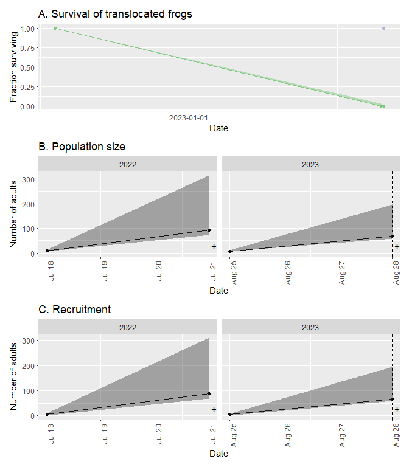

```r
library(ggplot2)
p1 <- plot_model(model_10114, what = "survival")
p1 <- p1 + ggtitle("A. Survival of translocated frogs") +
    expand_limits(y = 0) +
    theme(legend.position = "none")

p2 <- plot_model(model_10114, what = "abundance")
p2 <- p2 + ggtitle("B. Population size") +
    ylab("Number of adults") +
    expand_limits(y = 0)

p3 <- plot_model(model_10114, what = "recruitment")
p3 <- p3 + ggtitle("C. Recruitment") +
    ylab("Number of adults")

p1 / p2 / p3
```

## Create survival tables

| years_since_introduction | release_date | pit_tag_id | lo_survival | median_survival | hi_survival |
| --- | --- | --- | --- | --- | --- |
| 1 | 2022-07-21 | 900043000215607 | 0 | 0 | 0 |
| 1 | 2022-07-21 | 900043000215610 | 0 | 0 | 0 |
| 1 | 2022-07-21 | 900043000215625 | 0 | 0 | 0 |
| 1 | 2022-07-21 | 900043000215628 | 0 | 0 | 0 |
| 1 | 2022-07-21 | 900043000215634 | 0 | 0 | 0 |
| 1 | 2022-07-21 | 900043000215642 | 0 | 0 | 0 |
| 1 | 2022-07-21 | 900043000215644 | 0 | 0 | 0 |
| 1 | 2022-07-21 | 900043000215646 | 0 | 0 | 0 |
| 1 | 2022-07-21 | 900043000215658 | 0 | 0 | 0 |
| 1 | 2022-07-21 | 900043000215660 | 0 | 0 | 0 |

[output cut: 58 more lines]